# Gaussian Mixture Models

KDEs are computationally intensive because every data point is used in calculating each estimate.

## Mixture models

$f(x)=\displaystyle\sum^K_{k=1}\pi_kf_k(x)$

$\pi_k$: mixing proportions (or weights)

This is a data generating process.

Pick a distribution among our $K$ options by introducing a new variable.

$z \sim Multinomial(\pi_1, \pi_2, ..., \pi_k)$

### Gaussian Mixture Models

Assume a parametric mixture model, with parameters $\theta_k$ for the $k$th component.

$f(x)=\displaystyle\sum^K_{k=1}\pi_kf_k(x;\theta_k)$

We need to estimate each $\pi_1, ... , \pi_k$, $\mu_1, \mu_2, ... \mu_k$, $\sigma_1, \sigma_2, ... \sigma_k$

To do this, we can compute the maximum likelihood estimates (MLEs) for $\mu$ and $\sigma$ assuming one distribution.

The MLEs for the normal distribution are the sample mean and sample standard deviation.

However, we don't know which component an observation belongs to!

We can get the distribution of $z$ given the data.

### Expectation-Maximization (EM) algorithm

Alternate between:

- Pretending to know the probability each observation belongs to each group, to estimate the parameters of the components
- Pretending to know the parameters of the components, to estimate the probability each observation belongs to each group

Start with initial guesses about the parameters.

E-step: calculate $\hat z_{ik}$: expected membership of observation $i$ in cluster $k$

M-step: update parameter estimates with weighted MLE using $\hat z_{ik}$

$\hat z_{ik}$ is a soft membership of observation $i$ in cluster $k$.

You can assign observation $i$ to a cluster with the largest $\hat z_{ik}$

Measure cluster assignment uncertainty: $1 - max_k{\hat z_{ik}}$

Parameters determine the type of clusters.

In 1D, we have two options: equal and unequal variance

### Multivariate GMM

$f(x)=\displaystyle\sum^K_{k=1}\pi_kN(\bf{\mu_k}, \Sigma_k)$

$\mu_k$: vector of means

$\Sigma_k$: covariance matrix

We can control the volume, shape, and orientation of the covariance.

k-means has equal volume and spherical shape.

### Bayesian information criterion (BIC)

We can use a model selection procedure for determining which best characterizes the data.

m parameters and n observations

Penalizaes large models with many clusters without constraints

We can use BIC to choose the covariance constraints AND number of clusters $K$.

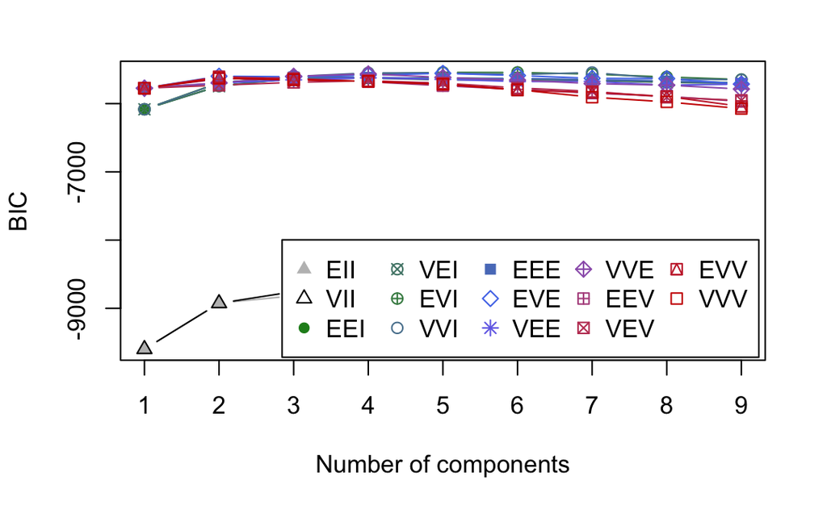